# complex_functions

```python
from matplotlib import pyplot as plt
import numpy as np
import matplotlib
```

```python
plt.rcParams["figure.dpi"] = 300     # Raise figure quality.
```

Plots of the ollowing functions on $\{x+iy \mid x \in [-1,1],\; y \in [-1,1]\}$.

- Plot $f(z) = z$ on $\{x + yi \mid x,y \in [-1,1]\}$.
- Plot $f(z) = \sqrt{z^2 + 1}$ on $\{x + iy \mid x,y \in [-3,3]\}$.
- $f(z) = z^n$ for $n=2,3,4$.
- $f(z) = z^3 - iz^4 - 3z^6$.

Meaning of singularity points:

$z^2$ has a zero of multiplicity 2 at the origin

$z^3$ has a zero of multiplicity 3 at the origin

$z^3 - iz^4 - 3z^6$ has a zero multiplicity 3 at the origin and three other zeros of multiplicity one

[figure not shown]

```python
# Problem 1
def plot_complex(f, window=[-1, 1, -1, 1], res=400, title=""):
    """Visualize the complex-valued function f:C->C on the (res x res) domain
    {a + bi | a in [r_min, r_max], b in [i_min, i_max]} by plotting the
    argument of f(z) and the magnitude of f(z) in separate subplots.

    Parameters:
        f (func): A function that accepts and returns arrays with complex entries.
        window ([r_min, r_max, i_min, i_max]): The real and imaginary domain bounds.
        res (int): The plot resolution. The domain should be res x res.
        title (str): A label for the function to set as the figure title.
            Use r"$<latex code>$" for pretty printing. For example, for the function
            f = lambda z: z**2 - np.sqrt(z), use title=r"$f(z) = z^2 - \sqrt{z}$".
    """

    fig, ax = plt.subplots(1,2, figsize=(3.5, 1.5))

    x = np.linspace(window[0], window[1], res)
    y = np.linspace(window[2], window[3], res)

    X,Y = np.meshgrid(x,y)

    Z = X + 1j*Y

    ax[0].pcolormesh(x,y,np.angle(f(Z)), cmap="twilight", vmin=-np.pi, vmax=np.pi)
    ax[1].pcolormesh(x,y,np.abs(f(Z)), cmap="viridis", norm=matplotlib.colors.LogNorm())
    fig.suptitle(title, fontsize=10)
    plt.tight_layout()
    plt.show()


f = lambda x: np.sqrt(x**2 + 1)
plot_complex(f, window=[-3, 3, -3, 3], res=400, title=r"$f(z) = z^2 - \sqrt{z}$")
```

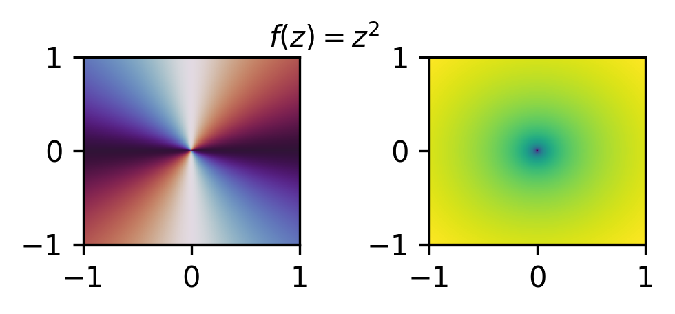

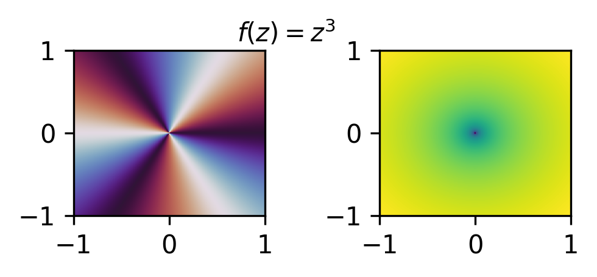

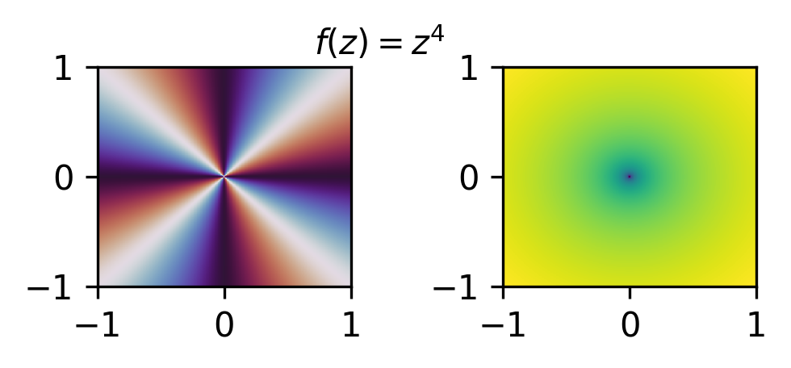

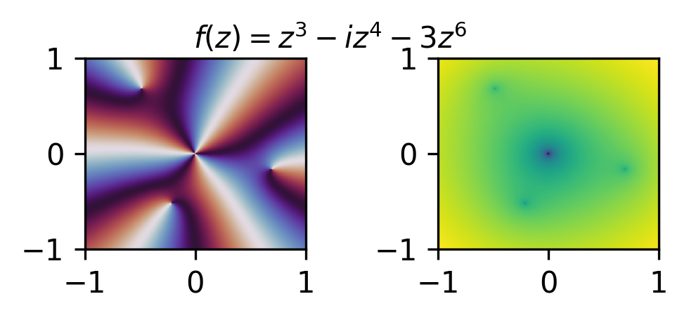

```python
Ns = [2,3,4]
for n in Ns:
  f = lambda z: z**n
  plot_complex(f, window=[-1, 1, -1, 1], res=400, title=f"$f(z) = z^{n}$")

f = lambda z: z**3 - 1j*z**4 - 3*z**6
plot_complex(f, window=[-1, 1, -1, 1], res=400, title=f"$f(z) = z^3 - iz^4 - 3z^6$")
```

Plot of the following functions and their poles

- $f(z) = z^{-n}$ for $n=1,2,3$.
- $f(z) = z^2 + iz^{-1} + z^{-3}$.

For the function:

$f(z) = z^{-n}$ for $n=1,2,3$.

n = 1 has a pole at the origin of order one n = 2 has a pole at the origin of order two n = 3 has a pole at the origin of order three

For the function:

$f(z) = z^2 + iz^{-1} + z^{-3}$

The origin is a pole of order three

There are also five zeros around the origin that all have order 1

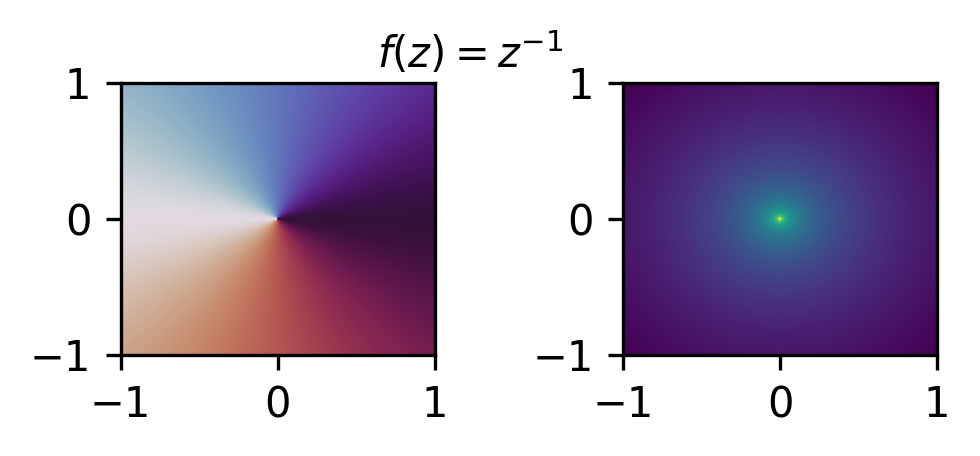

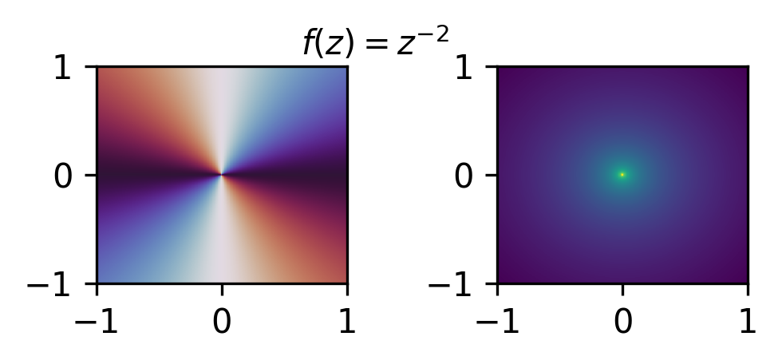

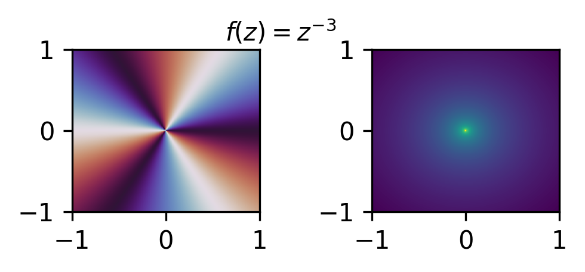

```python
Ns = [1,2,3]
for n in Ns:
  f = lambda z: z**(-1*n)
  plot_complex(f, window=[-1, 1, -1, 1], res=400, title="$f(z) = z^{-" + str(n) + "}$")
```

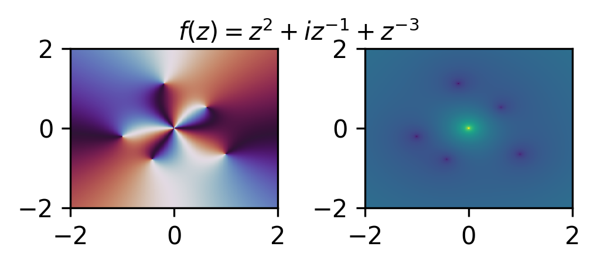

```python
# for n in Ns:
f = lambda z: z**(2)+1j*z**-1 + z**-3
plot_complex(f, window=[-2, 2, -2, 2], res=400, title="$f(z) = z^2 + iz^{-1} + z^{-3}$")
```

Plots of the following functions on the complex plane:

- $f(z) = -4z^5 + 2z^4 - 2z^3 - 4z^2 + 4z - 4$
- $f(z) = z^7 +6z^6 −131z^5 −419z^4 +4906z^3 −131z^2 −420z+4900$
- $f(z) = \frac{16z^4 + 32z^3 + 32z^2 + 16z + 4}{16z^4 - 16z^3 + 5z^2}$

The function:

$f(z) = -4z^5 + 2z^4 - 2z^3 - 4z^2 + 4z - 4$

has 5 zeros all of multiplicity 1.

The function:

The function:

$f(z) = \frac{16z^4 + 32z^3 + 32z^2 + 16z + 4}{16z^4 - 16z^3 + 5z^2}$

has two zeros to the left and three poles to the right. The zeros have multiplicity two, the more inner pole has multiplicity of two, and the outer poles have a multiplicity of one.

The function:

$f(z) = e^z$.

The function e^z can be split into it's real and imaginary part as e^(x+yi) = e^x *e^(y+i) = e^x + cos(y) + i*sin(y). As x increases, e^x approaches infinity, a pole, If x decreases, x approaches 0, a zero point of the function. As y increases or decreases it forms a sinusoidal wave that explains the wavelike pattern we have running across the imaginery axis.

The function:

$f(z) = \tan(z)$

Can be written asn sin(z)/cos(z) When traveling along the real axis, as cos and sin ossilates between -1 to 1 the function will have zero and singularities on regularly spaced intervals. However, if we extend into complex numbers we see that z will never be zero as there is always a non-zero imaginay term associated with the funciton and we also never hav multiplicities of pi as pi is a real number. As such, we only will have poles or zeros along the real axis line.

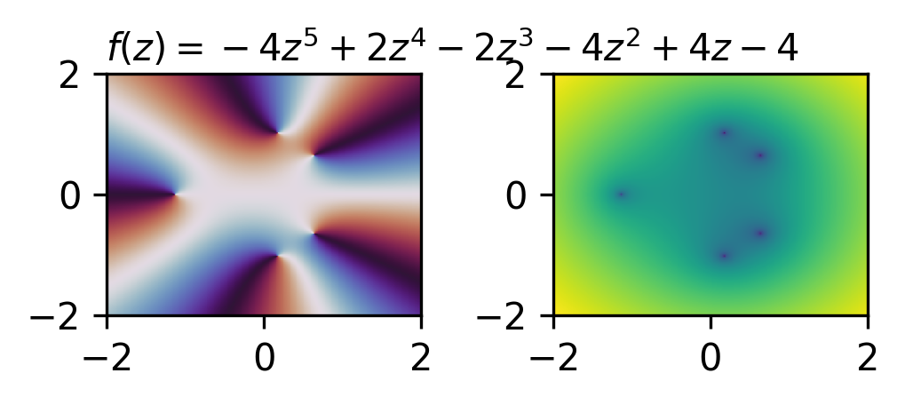

```python
# for n in Ns:
f = lambda z: -4*z**5 + 2*z**4 - 2*z**3 - 4*z**2 + 4*z - 4

plot_complex(f, window=[-2, 2, -2, 2], res=400, title="$f(z) = -4z^5 + 2z^4 - 2z^3 - 4z^2 + 4z - 4$")
```

[figure not shown]

```python
f = lambda z: (16*z**4 + 32*z**3 + 32*z**2 + 16*z + 4) / ( 16*z**4 - 16*z**3 + 5*z**2 )

plot_complex(f, window=[-2, 2, -2, 2], res=400, title="$f(z) = (16z^4 + 32z^3 + 32z^2 + 16z + 4)/(16z^4 - 16z^3 + 5z^2)$")
```

Plot of the following functions on the domain $\{x+iy\mid x,y\in[-8,8]\}$. Explain carefully what each graph reveals about the function and why the function behaves that way.

- $f(z) = e^z$.
- $f(z) = \tan(z)$.

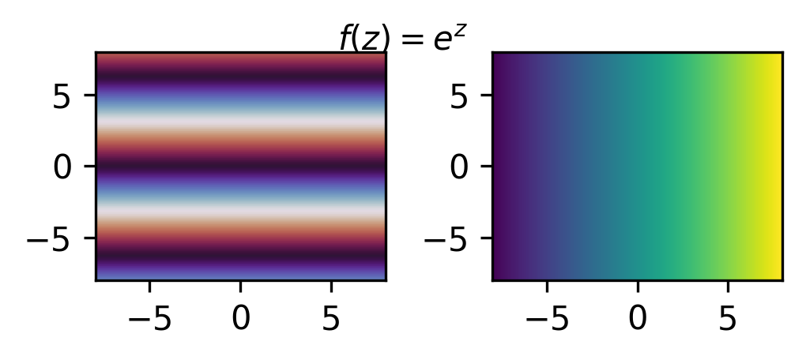

```python
f = lambda z: np.exp(z)

plot_complex(f, window=[-8, 8, -8, 8], res=400, title="$f(z) = e^z$")
```

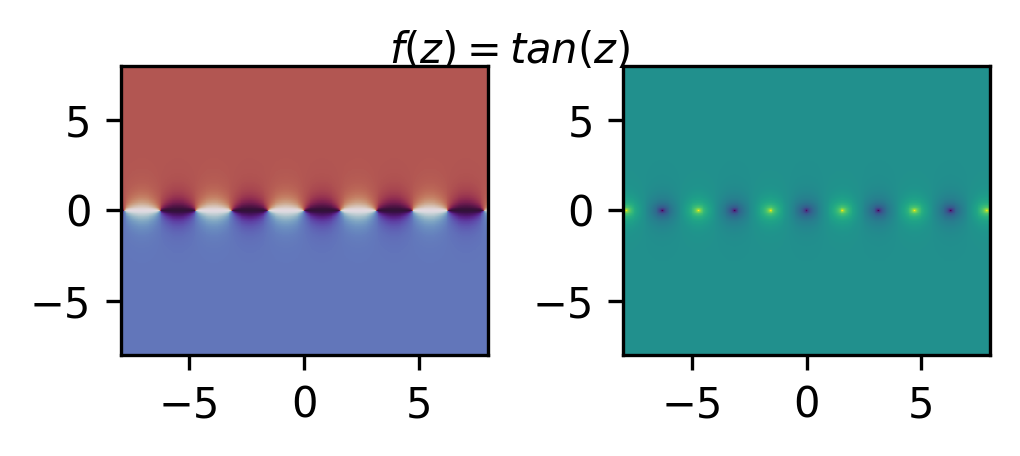

```python
f = lambda z: np.tan(z)

plot_complex(f, window=[-8, 8, -8, 8], res=400, title="$f(z) = tan(z)$")
```

- $f(z) = \sin\left(\frac{1}{100z}\right)$.

From a distance seems like a pole of order one at the origin. However, when we zoom in the function becomes extremely poorly behaved as we have an infnite amount of zeros along the real number line and a pole at the origin.

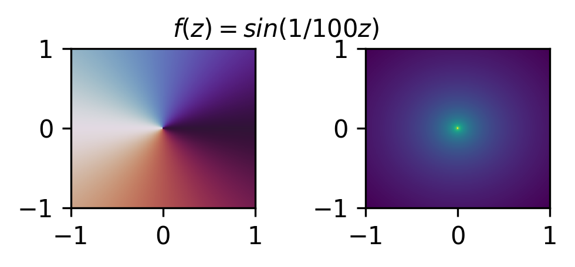

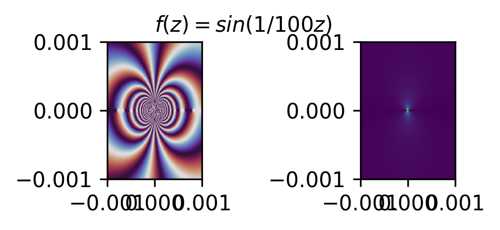

```python
f = lambda z: np.sin(1/(100*z))

plot_complex(f, window=[-1, 1, -1, 1], res=400, title="$f(z) = sin(1/100z)$")

plot_complex(f, window=[-.001, .001, -.001, .001], res=400, title="$f(z) = sin(1/100z)$")
plt.tight_layout()
```